# GEOM WHIM Descriptor MAE QC

Michael Tran

2026-04-30

This notebook demonstrates the structure and basic use of the final `MultiAssayExperiment` containing GEOM-derived WHIM descriptor assays and compound annotations.

WHIM descriptors were introduced by Todeschini, Gramatica, Provenzani, and Marengo in *Chemometrics and Intelligent Laboratory Systems*: https://doi.org/10.1016/0169-7439(95)80026-6.

## Load the MAE

```r
mae <- readRDS(mae_path)

assay_names <- names(experiments(mae))
assay_mats <- setNames(
  lapply(assay_names, \(assay_name) assay(experiments(mae)[[assay_name]])),
  assay_names
)

compound_metadata <- as.data.frame(metadata(mae)$Drug.Metadata) |>
  rownames_to_column("Compound.Key") |>
  as_tibble()

coldata <- as.data.frame(colData(mae)) |>
  as_tibble()

rowdata <- bind_rows(
  lapply(assay_names, \(assay_name) {
    as.data.frame(rowData(experiments(mae)[[assay_name]])) |>
      as_tibble() |>
      mutate(Assay = assay_name)
  })
)

mae
```

```
## A MultiAssayExperiment object of 3 listed
##  experiments with user-defined names and respective classes.
##  Containing an ExperimentList class object of length 3:
##  [1] WHIM_hp: SummarizedExperiment with 114 rows and 304348 columns
##  [2] WHIMS_avg: SummarizedExperiment with 114 rows and 304348 columns
##  [3] WHIMS_wavg: SummarizedExperiment with 114 rows and 304348 columns
## Functionality:
##  experiments() - obtain the ExperimentList instance
##  colData() - the primary/phenotype DataFrame
##  sampleMap() - the sample coordination DataFrame
##  `$`, `[`, `[[` - extract colData columns, subset, or experiment
##  *Format() - convert into a long or wide DataFrame
##  assays() - convert ExperimentList to a SimpleList of matrices
##  exportClass() - save data to flat files
```

## Dataset Overview

```r
assay_summary <- tibble(
  assay = assay_names,
  assay_name = vapply(
    assay_names,
    \(assay_name) {
      paste(assayNames(experiments(mae)[[assay_name]]), collapse = ", ")
    },
    character(1)
  ),
  features = vapply(
    assay_names,
    \(assay_name) nrow(assay_mats[[assay_name]]),
    integer(1)
  ),
  compounds = vapply(
    assay_names,
    \(assay_name) ncol(assay_mats[[assay_name]]),
    integer(1)
  ),
  feature_type = "WHIM descriptor features"
)

annotation_availability <- compound_metadata |>
  mutate(
    annotation_status = if_else(
      In.AnnotationDB,
      "AnnotationDB enriched",
      "No AnnotationDB match",
      missing = "No AnnotationDB match"
    )
  ) |>
  count(annotation_status, name = "compounds") |>
  mutate(
    fraction = compounds / sum(compounds),
    percent = scales::percent(fraction, accuracy = 0.1),
    label = paste0(
      annotation_status,
      "\n",
      scales::comma(compounds),
      " (",
      percent,
      ")"
    )
  )

overview_tbl <- tibble(
  quantity = c(
    "Pipeline ID",
    "Pipeline version",
    "Experiments",
    "Assays",
    "Compounds in colData",
    "Drug metadata records",
    "Source subsets",
    "WHIM features per assay",
    "Total assay columns",
    "Compounds with PubChem CID",
    "Compounds without PubChem CID",
    "Median total conformers",
    "Median unique conformers"
  ),
  value = c(
    metadata(mae)$Pipeline$ID,
    metadata(mae)$Pipeline$Version,
    fmt_count(length(experiments(mae))),
    paste(assay_names, collapse = ", "),
    fmt_count(nrow(coldata)),
    fmt_count(nrow(compound_metadata)),
    paste(sort(unique(compound_metadata$GEOM.Source.Subset)), collapse = ", "),
    fmt_count(unique(assay_summary$features)),
    fmt_count(sum(assay_summary$compounds)),
    fmt_count(sum(!is.na(compound_metadata$Pubchem.CID))),
    fmt_count(sum(is.na(compound_metadata$Pubchem.CID))),
    fmt_count(stats::median(
      compound_metadata$GEOM.Total.Conformers,
      na.rm = TRUE
    )),
    fmt_count(stats::median(
      compound_metadata$GEOM.Unique.Conformers,
      na.rm = TRUE
    ))
  )
)

kable(overview_tbl)
```

| quantity | value |
| --- | --- |
| Pipeline ID | geom |
| Pipeline version | v2.0.0 |
| Experiments | 3 |
| Assays | WHIM_hp, WHIMS_avg, WHIMS_wavg |
| Compounds in colData | 304,348 |
| Drug metadata records | 304,348 |
| Source subsets | drugs |
| WHIM features per assay | 114 |
| Total assay columns | 913,044 |
| Compounds with PubChem CID | 213,015 |
| Compounds without PubChem CID | 91,333 |
| Median total conformers | 245 |
| Median unique conformers | 51 |

```r
kable(assay_summary)
```

| assay | assay_name | features | compounds | feature_type |
| --- | --- | --- | --- | --- |
| WHIM_hp | values | 114 | 304348 | WHIM descriptor features |
| WHIMS_avg | values | 114 | 304348 | WHIM descriptor features |
| WHIMS_wavg | values | 114 | 304348 | WHIM descriptor features |

This MAE contains three WHIM descriptor assays. Rows are descriptor features and columns are compounds keyed by `GEOM.Source.SMILES`. The object is compound-level: each assay column represents one GEOM drug compound.

## Inspect the MAE Structure

The object layout is inspected directly below. The experiment container, assay names, compound-level metadata, sample map, and object-level metadata can all be accessed from the printed structure and the code shown in this section.

```r
mae
```

```
## A MultiAssayExperiment object of 3 listed
##  experiments with user-defined names and respective classes.
##  Containing an ExperimentList class object of length 3:
##  [1] WHIM_hp: SummarizedExperiment with 114 rows and 304348 columns
##  [2] WHIMS_avg: SummarizedExperiment with 114 rows and 304348 columns
##  [3] WHIMS_wavg: SummarizedExperiment with 114 rows and 304348 columns
## Functionality:
##  experiments() - obtain the ExperimentList instance
##  colData() - the primary/phenotype DataFrame
##  sampleMap() - the sample coordination DataFrame
##  `$`, `[`, `[[` - extract colData columns, subset, or experiment
##  *Format() - convert into a long or wide DataFrame
##  assays() - convert ExperimentList to a SimpleList of matrices
##  exportClass() - save data to flat files
```

```r
experiments(mae)
```

```
## ExperimentList class object of length 3:
##  [1] WHIM_hp: SummarizedExperiment with 114 rows and 304348 columns
##  [2] WHIMS_avg: SummarizedExperiment with 114 rows and 304348 columns
##  [3] WHIMS_wavg: SummarizedExperiment with 114 rows and 304348 columns
```

```r
colnames(colData(mae))
```

```
##  [1] "GEOM.Source.SMILES"     "Pubchem.CID"            "InChIKey"
##  [4] "GEOM.RDKit.SMILES"      "In.AnnotationDB"        "AnnotationDB.Name"
##  [7] "AnnotationDB.SMILES"    "GEOM.Source.Subset"     "GEOM.Canonical.SMILES"
## [10] "GEOM.Charge"            "GEOM.Total.Conformers"  "GEOM.Unique.Conformers"
## [13] "GEOM.Lowest.Energy"     "GEOM.Ensemble.Energy"
```

```r
head(as.data.frame(sampleMap(mae)))
```

```
##     assay                                             primary
## 1 WHIM_hp BrC(/C=C\\c1ccccc1)=N/Nc1nc(N2CCOCC2)nc(N2CCOCC2)n1
## 2 WHIM_hp            BrC(/C=N/N1CCN(Cc2ccccc2)CC1)=C/c1ccccc1
## 3 WHIM_hp  BrC(/C=N/Nc1nc(N2CCOCC2)nc(N2CCOCC2)n1)=C/c1ccccc1
## 4 WHIM_hp           BrC(=C\\c1ccccc1)/C=N/N1CCN(Cc2ccccc2)CC1
## 5 WHIM_hp            BrC(=C\\c1ccccc1)/C=N/N1CCN(c2ccccc2)CC1
## 6 WHIM_hp            BrC(=C\\c1ccccc1)/C=N/N1CCN(c2ccccn2)CC1
##                                               colname
## 1 BrC(/C=C\\c1ccccc1)=N/Nc1nc(N2CCOCC2)nc(N2CCOCC2)n1
## 2            BrC(/C=N/N1CCN(Cc2ccccc2)CC1)=C/c1ccccc1
## 3  BrC(/C=N/Nc1nc(N2CCOCC2)nc(N2CCOCC2)n1)=C/c1ccccc1
## 4           BrC(=C\\c1ccccc1)/C=N/N1CCN(Cc2ccccc2)CC1
## 5            BrC(=C\\c1ccccc1)/C=N/N1CCN(c2ccccc2)CC1
## 6            BrC(=C\\c1ccccc1)/C=N/N1CCN(c2ccccn2)CC1
```

```r
names(metadata(mae))
```

```
## [1] "Pipeline"      "Drug.Metadata"
```

The `sampleMap` has one row for each assay-compound pair. For every assay, both `primary` and `colname` are `GEOM.Source.SMILES`, so the same compound metadata row maps to that compound’s column in each WHIM assay.

## Compound Metadata

```r
compound_metadata |>
  select(
    GEOM.Source.SMILES,
    Pubchem.CID,
    InChIKey,
    In.AnnotationDB,
    AnnotationDB.Name,
    GEOM.Source.Subset,
    GEOM.Charge,
    GEOM.Total.Conformers,
    GEOM.Unique.Conformers,
    GEOM.Lowest.Energy,
    GEOM.Ensemble.Energy
  ) |>
  slice_head(n = 8) |>
  kable()
```

| GEOM.Source.SMILES | Pubchem.CID | InChIKey | In.AnnotationDB | AnnotationDB.Name | GEOM.Source.Subset | GEOM.Charge | GEOM.Total.Conformers | GEOM.Unique.Conformers | GEOM.Lowest.Energy | GEOM.Ensemble.Energy |
| --- | --- | --- | --- | --- | --- | --- | --- | --- | --- | --- |
| BrC(/C=Cccccc1)=N/Nc1nc(N2CCOCC2)nc(N2CCOCC2)n1 | NA | QEJRAQJWLWLEOF-PRMXUTLTSA-N | FALSE | NA | drugs | 0 | 83 | 27 | -87.80248 | 0.282 |
| BrC(/C=N/N1CCN(Cc2ccccc2)CC1)=C/c1ccccc1 | 6879954 | DYNORDCFBLDDQF-RQRAPYSXSA-N | TRUE | (E)-4-benzyl-N-((E)-2-bromo-3-phenylallylidene)piperazin-1-amine | drugs | 0 | 351 | 130 | -66.85172 | 0.479 |
| BrC(/C=N/Nc1nc(N2CCOCC2)nc(N2CCOCC2)n1)=C/c1ccccc1 | 6877346 | VOIWWGCVDFCTAW-RTMICUHXSA-N | TRUE | N-(2-Bromo-3-phenyl-allylidene)-N’-(4,6-di-morpholin-4-yl-[1,3,5]triazin-2-yl)-hydrazine | drugs | 0 | 34 | 10 | -87.79648 | 0.169 |
| BrC(=Cccccc1)/C=N/N1CCN(Cc2ccccc2)CC1 | 5342758 | DYNORDCFBLDDQF-IJDGKNKPSA-N | TRUE | 4-benzyl-N-(2-bromo-3-phenyl-2-propen-1-ylidene)-1-piperazinamine | drugs | 0 | 319 | 141 | -66.85031 | 0.296 |
| BrC(=Cccccc1)/C=N/N1CCN(c2ccccc2)CC1 | 5727615 | JASQRDIPLVCSQS-TXWVUNSISA-N | TRUE | N-(2-Bromo-3-phenyl-2-propenylidene)-4-phenyl-1-piperazinamine | drugs | 0 | 176 | 23 | -63.69226 | 0.384 |
| BrC(=Cccccc1)/C=N/N1CCN(c2ccccn2)CC1 | 6897665 | FZNNISGQTKDUIM-WANMUPLOSA-N | TRUE | N-(2-bromo-3-phenyl-2-propen-1-ylidene)-4-(2-pyridinyl)-1-piperazinamine | drugs | 0 | 171 | 66 | -63.97501 | 0.509 |
| BrC(=Cccccc1)/C=N/Nc1ccc2nncn2n1 | 6862203 | JTLAOTXPOJNRJW-OOBCCFMBSA-N | TRUE | N-[(E)-[(Z)-2-bromo-3-phenylprop-2-enylidene]amino]-[1,2,4]triazolo[4,3-b]pyridazin-6-amine | drugs | 0 | 24 | 7 | -57.13764 | 0.206 |
| BrC(=Cccccc1)/C=N/Nc1nc(N2CCOCC2)nc(N2CCOCC2)n1 | 6877347 | VOIWWGCVDFCTAW-WKSPYJHRSA-N | TRUE | N-(2-Bromo-3-phenyl-allylidene)-N’-(4,6-di-morpholin-4-yl-[1,3,5]triazin-2-yl)-h | drugs | 0 | 162 | 28 | -87.79328 | 0.277 |

The main fields commonly used in downstream analysis are:

- `GEOM.Source.SMILES`: the GEOM source molecule key used as the MAE primary key and assay column name.
- `Pubchem.CID`: the PubChem compound identifier used to join back to the base harmonized drug dataset.
- `InChIKey`: the structure-level identifier derived from the representative GEOM conformer molecule.
- `GEOM.RDKit.SMILES` and `GEOM.Canonical.SMILES`: RDKit-derived structures retained for comparison with the source key.
- `In.AnnotationDB`: whether the compound mapped to AnnotationDB metadata.
- `GEOM.Total.Conformers` and `GEOM.Unique.Conformers`: GEOM conformer counts carried into the compound-level metadata.
- `GEOM.Lowest.Energy` and `GEOM.Ensemble.Energy`: GEOM energy summaries for the compound.

```r
metadata_completeness <- compound_metadata |>
  summarise(
    across(
      c(
        Pubchem.CID,
        InChIKey,
        GEOM.RDKit.SMILES,
        GEOM.Canonical.SMILES,
        AnnotationDB.Name,
        AnnotationDB.SMILES,
        GEOM.Charge,
        GEOM.Total.Conformers,
        GEOM.Unique.Conformers,
        GEOM.Lowest.Energy,
        GEOM.Ensemble.Energy
      ),
      \(value) sum(is_present(value))
    )
  ) |>
  pivot_longer(
    cols = everything(),
    names_to = "field",
    values_to = "present"
  ) |>
  mutate(
    missing = nrow(compound_metadata) - present,
    percent_present = fmt_percent(present / nrow(compound_metadata))
  ) |>
  arrange(desc(present))

kable(metadata_completeness)
```

| field | present | missing | percent_present |
| --- | --- | --- | --- |
| GEOM.RDKit.SMILES | 304348 | 0 | 100.0% |
| GEOM.Canonical.SMILES | 304348 | 0 | 100.0% |
| GEOM.Charge | 304348 | 0 | 100.0% |
| InChIKey | 304346 | 2 | 100.0% |
| GEOM.Total.Conformers | 304294 | 54 | 100.0% |
| GEOM.Unique.Conformers | 304294 | 54 | 100.0% |
| GEOM.Lowest.Energy | 304294 | 54 | 100.0% |
| GEOM.Ensemble.Energy | 304294 | 54 | 100.0% |
| Pubchem.CID | 213015 | 91333 | 70.0% |
| AnnotationDB.SMILES | 213015 | 91333 | 70.0% |
| AnnotationDB.Name | 211416 | 92932 | 69.5% |

```r
kable(
  annotation_availability |>
    select(annotation_status, compounds, percent)
)
```

| annotation_status | compounds | percent |
| --- | --- | --- |
| AnnotationDB enriched | 213015 | 70.0% |
| No AnnotationDB match | 91333 | 30.0% |

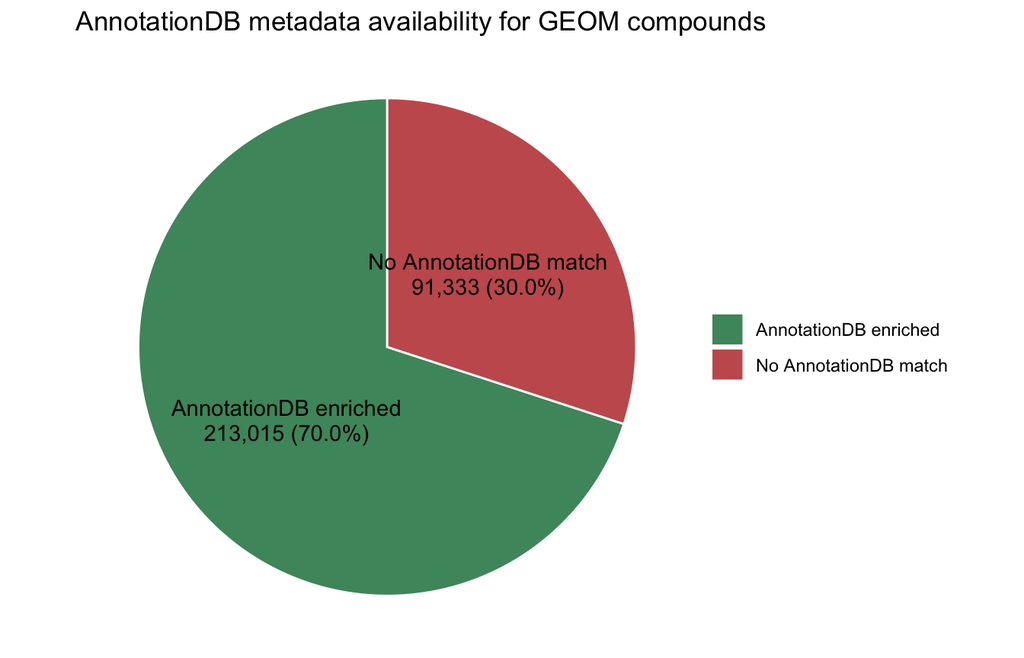

```r
ggplot(
  annotation_availability,
  aes(x = "", y = fraction, fill = annotation_status)
) +
  geom_col(width = 1, color = "white") +
  geom_text(
    aes(label = label),
    position = position_stack(vjust = 0.5),
    lineheight = 0.95
  ) +
  coord_polar(theta = "y") +
  scale_fill_manual(values = c("#4C956C", "#C75C5C")) +
  labs(
    title = "AnnotationDB metadata availability for GEOM compounds",
    fill = NULL
  ) +
  theme_void()
```

## Conformer Landscape

GEOM provides conformer-level structure summaries. The MAE stores compound-level conformer counts and energy summaries in `colData`.

```r
conformer_summary_tbl <- compound_metadata |>
  summarise(
    compounds = n(),
    total_conformer_min = min(GEOM.Total.Conformers, na.rm = TRUE),
    total_conformer_median = stats::median(GEOM.Total.Conformers, na.rm = TRUE),
    total_conformer_mean = mean(GEOM.Total.Conformers, na.rm = TRUE),
    total_conformer_max = max(GEOM.Total.Conformers, na.rm = TRUE),
    unique_conformer_min = min(GEOM.Unique.Conformers, na.rm = TRUE),
    unique_conformer_median = stats::median(
      GEOM.Unique.Conformers,
      na.rm = TRUE
    ),
    unique_conformer_mean = mean(GEOM.Unique.Conformers, na.rm = TRUE),
    unique_conformer_max = max(GEOM.Unique.Conformers, na.rm = TRUE)
  ) |>
  mutate(across(everything(), fmt_number))

kable(conformer_summary_tbl)
```

| compounds | total_conformer_min | total_conformer_median | total_conformer_mean | total_conformer_max | unique_conformer_min | unique_conformer_median | unique_conformer_mean | unique_conformer_max |
| --- | --- | --- | --- | --- | --- | --- | --- | --- |
| 304,348 | 1 | 245 | 389.03 | 11,734 | 1 | 51 | 102.61 | 7,451 |

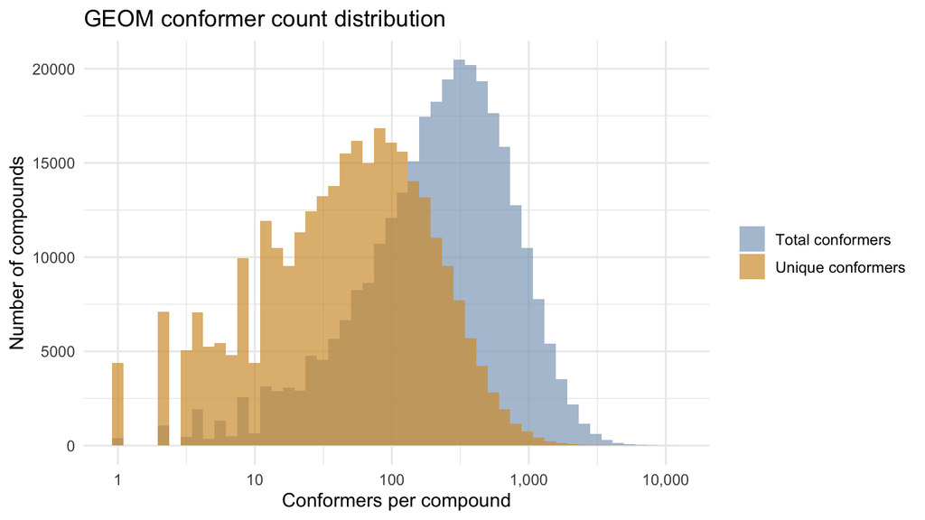

```r
compound_metadata |>
  transmute(
    `Total conformers` = pmax(GEOM.Total.Conformers, 1),
    `Unique conformers` = pmax(GEOM.Unique.Conformers, 1)
  ) |>
  pivot_longer(
    cols = everything(),
    names_to = "count_type",
    values_to = "conformers"
  ) |>
  ggplot(aes(x = conformers, fill = count_type)) +
  geom_histogram(bins = 50, alpha = 0.7, position = "identity") +
  scale_x_log10(labels = scales::comma) +
  scale_fill_manual(values = c("#8EA8C3", "#D49A3A")) +
  labs(
    title = "GEOM conformer count distribution",
    x = "Conformers per compound",
    y = "Number of compounds",
    fill = NULL
  )
```

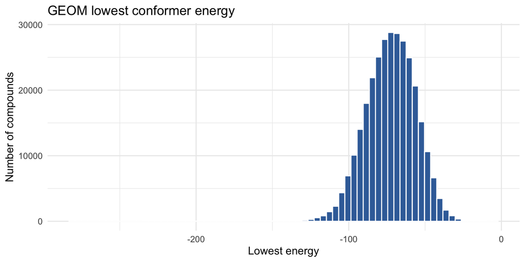

```r
compound_metadata |>
  filter(is.finite(GEOM.Lowest.Energy)) |>
  ggplot(aes(x = GEOM.Lowest.Energy)) +
  geom_histogram(bins = 70, fill = "#3B6EA8", color = "white") +
  labs(
    title = "GEOM lowest conformer energy",
    x = "Lowest energy",
    y = "Number of compounds"
  )
```

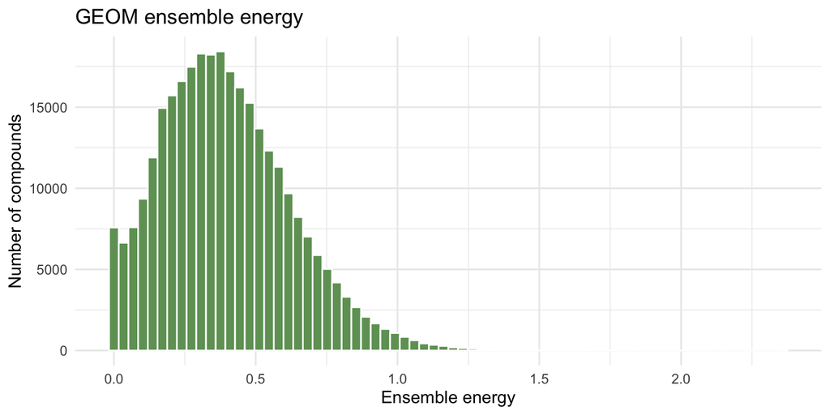

```r
compound_metadata |>
  filter(is.finite(GEOM.Ensemble.Energy)) |>
  ggplot(aes(x = GEOM.Ensemble.Energy)) +
  geom_histogram(bins = 70, fill = "#6E9F64", color = "white") +
  labs(
    title = "GEOM ensemble energy",
    x = "Ensemble energy",
    y = "Number of compounds"
  )
```

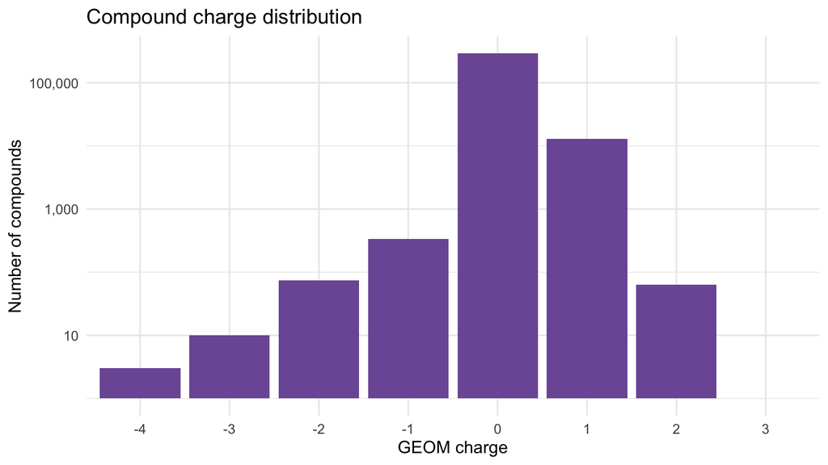

```r
compound_metadata |>
  count(GEOM.Charge, name = "compounds") |>
  ggplot(aes(x = factor(GEOM.Charge), y = compounds)) +
  geom_col(fill = "#7D5BA6") +
  scale_y_log10(labels = scales::comma) +
  labs(
    title = "Compound charge distribution",
    x = "GEOM charge",
    y = "Number of compounds"
  )
```

```r
compound_metadata |>
  arrange(desc(GEOM.Total.Conformers), GEOM.Source.SMILES) |>
  select(
    GEOM.Source.SMILES,
    Pubchem.CID,
    In.AnnotationDB,
    GEOM.Total.Conformers,
    GEOM.Unique.Conformers,
    GEOM.Lowest.Energy,
    GEOM.Ensemble.Energy
  ) |>
  slice_head(n = 12) |>
  kable()
```

| GEOM.Source.SMILES | Pubchem.CID | In.AnnotationDB | GEOM.Total.Conformers | GEOM.Unique.Conformers | GEOM.Lowest.Energy | GEOM.Ensemble.Energy |
| --- | --- | --- | --- | --- | --- | --- |
| C/C=C()C(=O)OC1C(C)=C2C(C1OC(=O)CCCCC)C(C)(OC(C)=O)CC(OC(=O)CCC)C1(O)C2OC(=O)C1(C)O | NA | FALSE | 11734 | 476 | -140.91384 | 0.861 |
| CCCCCCCCCCCCCCCC(=O)OC(C)C | 8907 | TRUE | 11180 | 7451 | -68.26109 | 1.276 |
| CC(C)=CCC/C(C)=C/CC/C(C)=C/CC/C=C()CC/C=C()CCC=C(C)C | 638072 | TRUE | 10889 | 2696 | -89.65852 | 0.218 |
| CCCCCCCCCCCCCN+(C)Cc1ccccc1 | 2330 | TRUE | 9549 | 5948 | -70.05975 | 1.580 |
| Cc1c2oc3c(C)ccc(C(=O)OC(C)C4NC(=O)C(C(C)C)N(C)C(=O)CN(C)C(=O)C5CCCN5C(=O)C(C(C)C)NC4=O)c3nc-2c(C(=O)OC(C)C2NC(=O)C(C(C)C)N(C)C(=O)CN(C)C(=O)C3CCCN3C(=O)C(C(C)C)NC2=O)c(N)c1=O | NA | FALSE | 9292 | 146 | -277.15945 | 0.472 |
| CCCCC@@HNCC1CCC(C(C)(C)C)CC1 | NA | FALSE | 8604 | 3555 | -76.72874 | 0.783 |
| CO[C@H]1CC@HOC@@H[C@@H]1OC(C)=O | NA | FALSE | 8525 | 251 | -186.04283 | 0.370 |
| CC(=O)CCC=C(C)CCC=C(C)CCC=C(C)CCC=C(C)C | NA | FALSE | 8438 | 3518 | -72.63666 | 1.171 |
| CC(C)=CCC/C(C)=C/CC/C(C)=C/CCC(=O)OC/C=C()CCC=C(C)C | 5282182 | TRUE | 8411 | 2739 | -88.33808 | 0.286 |
| CCCCCCCCCCCCCCCC(=O)C(F)(F)F | 4670 | TRUE | 8230 | 6325 | -70.50133 | 1.546 |
| CCCCS(=O)CC(CS(=O)CCCC)OC(=O)c1ccc(C)cc1 | NA | FALSE | 8129 | 2320 | -78.74564 | 1.052 |
| CCC(=O)O[C@H]1C@HOC@@HC[C@@]1(C)O | NA | FALSE | 8102 | 520 | -185.97688 | 1.006 |

## WHIM Descriptor Assays

```r
rowdata |>
  select(Assay, Feature.ID, Feature.Index, Assay.Name) |>
  filter(Assay == "WHIM_hp") |>
  slice_head(n = 6) |>
  kable()
```

| Assay | Feature.ID | Feature.Index | Assay.Name |
| --- | --- | --- | --- |
| WHIM_hp | WHIM_001 | 1 | WHIM_hp |
| WHIM_hp | WHIM_002 | 2 | WHIM_hp |
| WHIM_hp | WHIM_003 | 3 | WHIM_hp |
| WHIM_hp | WHIM_004 | 4 | WHIM_hp |
| WHIM_hp | WHIM_005 | 5 | WHIM_hp |
| WHIM_hp | WHIM_006 | 6 | WHIM_hp |

```r
assay_quality_tbl <- bind_rows(
  lapply(assay_names, \(assay_name) {
    mat <- assay_mats[[assay_name]]
    sampled_values <- sample_values(mat)
    tibble(
      assay = assay_name,
      features = nrow(mat),
      compounds = ncol(mat),
      entries = length(mat),
      missing_entries = sum(is.na(mat)),
      non_finite_entries = sum(!is.finite(mat)),
      sampled_min = min(sampled_values, na.rm = TRUE),
      sampled_median = stats::median(sampled_values, na.rm = TRUE),
      sampled_mean = mean(sampled_values, na.rm = TRUE),
      sampled_max = max(sampled_values, na.rm = TRUE)
    )
  })
) |>
  mutate(
    across(
      c(features, compounds, entries, missing_entries, non_finite_entries),
      fmt_count
    ),
    across(
      c(sampled_min, sampled_median, sampled_mean, sampled_max),
      \(value) fmt_number(value, 4)
    )
  )

kable(assay_quality_tbl)
```

| assay | features | compounds | entries | missing_entries | non_finite_entries | sampled_min | sampled_median | sampled_mean | sampled_max |
| --- | --- | --- | --- | --- | --- | --- | --- | --- | --- |
| WHIM_hp | 114 | 304,348 | 34,695,672 | 0 | 0 | 0 | 0.4960 | 12.7996 | 2,994.671 |
| WHIMS_avg | 114 | 304,348 | 34,695,672 | 0 | 0 | 0 | 0.5006 | 14.2520 | 3,030.899 |
| WHIMS_wavg | 114 | 304,348 | 34,695,672 | 0 | 0 | 0 | 0.4955 | 13.0628 | 2,997.577 |

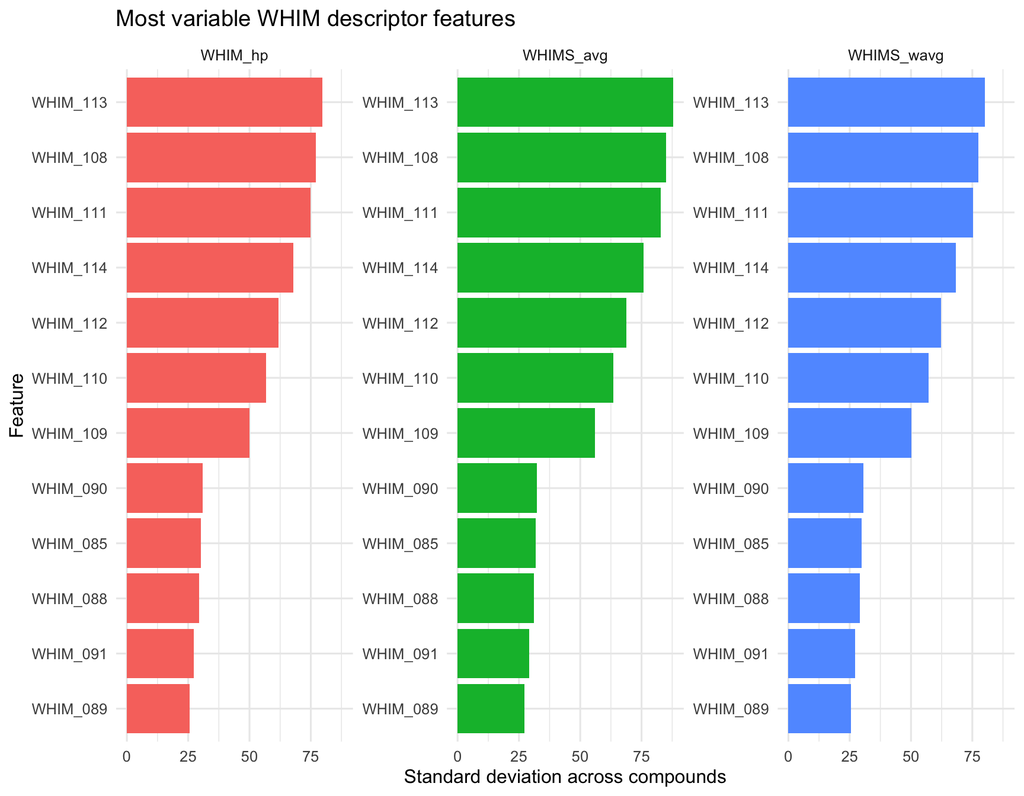

```r
feature_stats |>
  group_by(Assay) |>
  slice_max(SD, n = 12, with_ties = FALSE) |>
  ungroup() |>
  mutate(
    Feature.Label = reorder(Feature.ID, SD)
  ) |>
  ggplot(aes(x = SD, y = Feature.Label, fill = Assay)) +
  geom_col(show.legend = FALSE) +
  facet_wrap(~Assay, scales = "free_y") +
  labs(
    title = "Most variable WHIM descriptor features",
    x = "Standard deviation across compounds",
    y = "Feature"
  )
```

## Descriptor-Space UMAP

The UMAP below is a visualization of a reproducible sample of compounds using all three WHIM assay families. Each point is one compound-level descriptor profile.

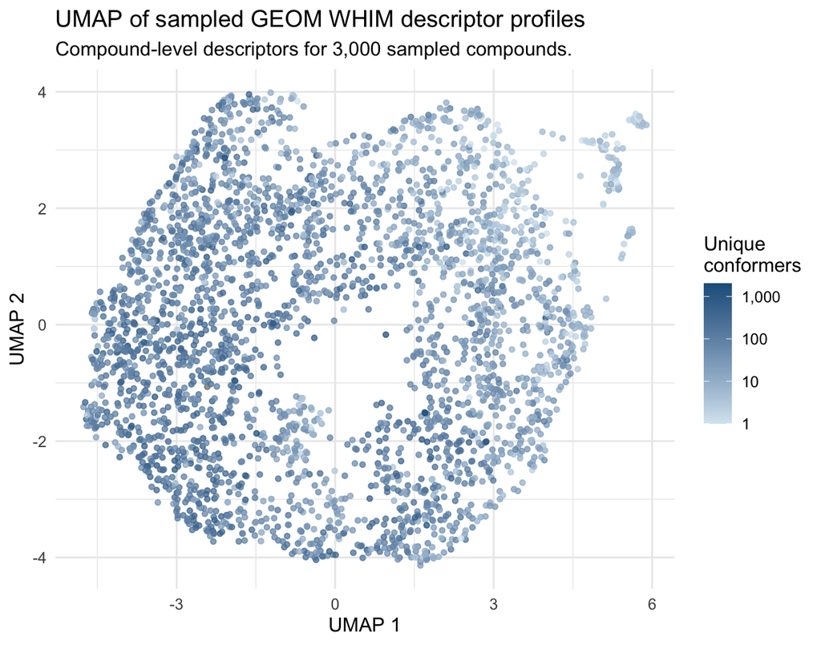

```r
set.seed(20260430)

umap_compound_source <- compound_metadata |>
  filter(GEOM.Source.SMILES %in% colnames(assay_mats[[assay_names[[1L]]]]))

umap_sample_n <- min(3000L, nrow(umap_compound_source))

umap_compounds <- umap_compound_source |>
  slice_sample(n = umap_sample_n)

umap_input <- do.call(
  cbind,
  lapply(assay_names, \(assay_name) {
    mat <- assay_mats[[assay_name]][,
      umap_compounds$GEOM.Source.SMILES,
      drop = FALSE
    ]
    t(mat)
  })
)

umap_input <- scale(umap_input)
umap_input[is.na(umap_input)] <- 0

umap_layout <- uwot::umap(
  umap_input,
  n_neighbors = 15,
  min_dist = 0.2,
  metric = "cosine",
  n_threads = 1,
  n_sgd_threads = 1,
  verbose = FALSE
)

umap_tbl <- as_tibble(umap_layout, .name_repair = \(x) c("UMAP1", "UMAP2")) |>
  bind_cols(
    umap_compounds |>
      select(
        GEOM.Source.SMILES,
        GEOM.Unique.Conformers,
        GEOM.Total.Conformers
      )
  ) |>
  mutate(Unique.Conformers.For.Color = pmax(GEOM.Unique.Conformers, 1))

ggplot(
  umap_tbl,
  aes(
    x = UMAP1,
    y = UMAP2,
    color = Unique.Conformers.For.Color
  )
) +
  geom_point(alpha = 0.75, size = 1.2) +
  scale_color_gradient(
    low = "#D8E7F1",
    high = "#1F5F8B",
    trans = "log10",
    labels = scales::comma
  ) +
  labs(
    title = "UMAP of sampled GEOM WHIM descriptor profiles",
    subtitle = paste0(
      "Compound-level descriptors for ",
      scales::comma(nrow(umap_tbl)),
      " sampled compounds."
    ),
    x = "UMAP 1",
    y = "UMAP 2",
    color = "Unique\nconformers"
  )
```

## Assay Relationship Checks

The three WHIM assays use the same compounds and feature count, but summarize conformer information differently. The plot below compares normalized per-compound descriptor-vector distances between assay pairs.

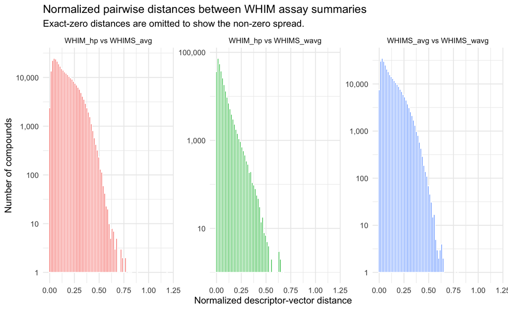

```r
assay_pairs <- tribble(
  ~pair                     , ~assay_a    , ~assay_b     , ~denominator_assay ,
  "WHIM_hp vs WHIMS_avg"    , "WHIM_hp"   , "WHIMS_avg"  , "WHIMS_avg"        ,
  "WHIM_hp vs WHIMS_wavg"   , "WHIM_hp"   , "WHIMS_wavg" , "WHIMS_wavg"       ,
  "WHIMS_avg vs WHIMS_wavg" , "WHIMS_avg" , "WHIMS_wavg" , "WHIMS_avg"
)

assay_distance_tbl <- bind_rows(
  lapply(seq_len(nrow(assay_pairs)), \(index) {
    difference <- assay_mats[[assay_pairs$assay_a[[index]]]] -
      assay_mats[[assay_pairs$assay_b[[index]]]]
    absolute_distance <- sqrt(colSums(difference * difference, na.rm = TRUE))
    denominator_norm <- sqrt(
      colSums(
        assay_mats[[assay_pairs$denominator_assay[[index]]]]^2,
        na.rm = TRUE
      )
    )

    tibble(
      pair = assay_pairs$pair[[index]],
      normalized_distance = absolute_distance /
        pmax(
          denominator_norm,
          .Machine$double.eps
        )
    )
  })
)

assay_distance_tbl |>
  filter(normalized_distance > 0) |>
  ggplot(aes(x = normalized_distance, fill = pair)) +
  geom_histogram(bins = 80, color = "white", show.legend = FALSE) +
  facet_wrap(~pair, scales = "free_y") +
  scale_y_log10(labels = scales::comma) +
  labs(
    title = "Normalized pairwise distances between WHIM assay summaries",
    subtitle = "Exact-zero distances are omitted to show the non-zero spread.",
    x = "Normalized descriptor-vector distance",
    y = "Number of compounds"
  )
```

## High-Variance Descriptor Snapshot

This heatmap shows the most variable descriptor rows across compounds with the largest number of unique conformers. Values are scaled by descriptor row for visualization.

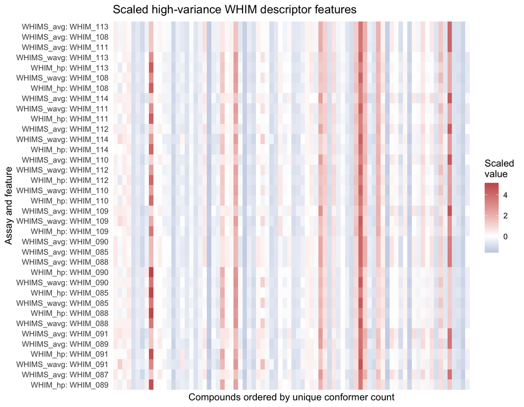

```r
top_heatmap_features <- feature_stats |>
  arrange(desc(SD)) |>
  slice_head(n = 36) |>
  mutate(Feature.Key = paste(Assay, Feature.ID, sep = ": "))

top_heatmap_compounds <- compound_metadata |>
  arrange(desc(GEOM.Unique.Conformers), GEOM.Source.SMILES) |>
  slice_head(n = 80) |>
  pull(GEOM.Source.SMILES)

heatmap_mat <- do.call(
  rbind,
  lapply(seq_len(nrow(top_heatmap_features)), \(index) {
    assay_name <- top_heatmap_features$Assay[[index]]
    feature_id <- top_heatmap_features$Feature.ID[[index]]
    values <- assay_mats[[assay_name]][
      feature_id,
      top_heatmap_compounds,
      drop = FALSE
    ]
    rownames(values) <- top_heatmap_features$Feature.Key[[index]]
    values
  })
)

heatmap_scaled <- t(scale(t(heatmap_mat)))
heatmap_scaled[!is.finite(heatmap_scaled)] <- 0

heatmap_tbl <- as.data.frame(heatmap_scaled) |>
  rownames_to_column("Feature.Key") |>
  as_tibble() |>
  pivot_longer(
    cols = -Feature.Key,
    names_to = "GEOM.Source.SMILES",
    values_to = "Scaled.Value"
  ) |>
  mutate(
    Feature.Key = factor(
      Feature.Key,
      levels = rev(top_heatmap_features$Feature.Key)
    ),
    GEOM.Source.SMILES = factor(
      GEOM.Source.SMILES,
      levels = top_heatmap_compounds
    )
  )

ggplot(
  heatmap_tbl,
  aes(x = GEOM.Source.SMILES, y = Feature.Key, fill = Scaled.Value)
) +
  geom_tile() +
  scale_fill_gradient2(
    low = "#3B6EA8",
    mid = "white",
    high = "#C75C5C",
    midpoint = 0
  ) +
  labs(
    title = "Scaled high-variance WHIM descriptor features",
    x = "Compounds ordered by unique conformer count",
    y = "Assay and feature",
    fill = "Scaled\nvalue"
  ) +
  theme(
    axis.text.x = element_blank(),
    axis.ticks.x = element_blank(),
    panel.grid = element_blank()
  )
```

## Basic Access Patterns

The MAE can be used directly as an analysis-ready compound descriptor resource. Most analyses will either use one WHIM assay at a time or concatenate assay families after confirming that the descriptor families are appropriate for the question.

```r
example_compound <- compound_metadata |>
  filter(In.AnnotationDB) |>
  arrange(desc(GEOM.Unique.Conformers), GEOM.Source.SMILES) |>
  slice(1) |>
  pull(GEOM.Source.SMILES)

example_metadata <- compound_metadata |>
  filter(GEOM.Source.SMILES == example_compound) |>
  select(
    GEOM.Source.SMILES,
    Pubchem.CID,
    InChIKey,
    AnnotationDB.Name,
    GEOM.Total.Conformers,
    GEOM.Unique.Conformers,
    GEOM.Lowest.Energy,
    GEOM.Ensemble.Energy
  )

kable(example_metadata)
```

| GEOM.Source.SMILES | Pubchem.CID | InChIKey | AnnotationDB.Name | GEOM.Total.Conformers | GEOM.Unique.Conformers | GEOM.Lowest.Energy | GEOM.Ensemble.Energy |
| --- | --- | --- | --- | --- | --- | --- | --- |
| CCCCCCCCCCCCCCCC(=O)OC(C)C | 8907 | XUGNVMKQXJXZCD-UHFFFAOYSA-N | Isopropyl Palmitate | 11180 | 7451 | -68.26109 | 1.276 |

```r
example_descriptors <- bind_rows(
  lapply(assay_names, \(assay_name) {
    tibble(
      Assay = assay_name,
      Feature.ID = rownames(assay_mats[[assay_name]]),
      value = assay_mats[[assay_name]][, example_compound]
    )
  })
) |>
  arrange(Assay, desc(abs(value))) |>
  group_by(Assay) |>
  slice_head(n = 3) |>
  ungroup()

kable(example_descriptors)
```

| Assay | Feature.ID | value |
| --- | --- | --- |
| WHIMS_avg | WHIM_113 | 247.8403 |
| WHIMS_avg | WHIM_108 | 240.7502 |
| WHIMS_avg | WHIM_111 | 237.2047 |
| WHIMS_wavg | WHIM_113 | 184.0387 |
| WHIMS_wavg | WHIM_108 | 179.0185 |
| WHIMS_wavg | WHIM_111 | 175.2372 |
| WHIM_hp | WHIM_113 | 161.1130 |
| WHIM_hp | WHIM_108 | 156.5930 |
| WHIM_hp | WHIM_111 | 153.0700 |

```r
pubchem_subset <- compound_metadata |>
  filter(!is.na(Pubchem.CID)) |>
  slice_head(n = 100) |>
  pull(GEOM.Source.SMILES)

whim_hp_subset <- assay_mats[["WHIM_hp"]][, pubchem_subset, drop = FALSE]

tibble(
  subset = "First 100 PubChem-mapped GEOM compounds",
  compounds = ncol(whim_hp_subset),
  features = nrow(whim_hp_subset)
) |>
  kable()
```

| subset | compounds | features |
| --- | --- | --- |
| First 100 PubChem-mapped GEOM compounds | 100 | 114 |

```r
tibble(
  object = c(
    "WHIM_hp feature_by_compound_matrix",
    "WHIM_hp compound_by_feature_matrix"
  ),
  rows = c(nrow(assay_mats[["WHIM_hp"]]), ncol(assay_mats[["WHIM_hp"]])),
  columns = c(ncol(assay_mats[["WHIM_hp"]]), nrow(assay_mats[["WHIM_hp"]]))
) |>
  mutate(
    rows = fmt_count(rows),
    columns = fmt_count(columns)
  ) |>
  kable()
```

| object | rows | columns |
| --- | --- | --- |
| WHIM_hp feature_by_compound_matrix | 114 | 304,348 |
| WHIM_hp compound_by_feature_matrix | 304,348 | 114 |

The compound-by-feature orientation is typically the convenient format for machine learning or clustering workflows, while the feature-by-compound orientation matches the stored `SummarizedExperiment` assays.